# DU Bii - module 3: R and stats

## **Session 2: practical on figures**

*Thursday 4th of March, 2021*

teachers: Claire Vandiedonck & Magali Berland; helpers: Antoine Bridier-Nahmias, Yves Clément, Bruno Toupance, Jacques van Helden

*Content of this tutorial:*

- Personnalisation du graphique
- Création de figures avec R base selon le typpe de variables: qualitatives ou quantitatives

## **Before going further**

**Caution:**  
**1. Create a new directory "Rsession2"** in your home with a right click in the left-hand panel of the lab.  
**2. Save a backup copy of this notebook in this folder** : in the left-hand panel, right-click on this file and select "Duplicate" and add your name, e.g: "tutorial_functions_vandiedonck.ipynb" and move it to the proper folder  
You can also make backups during the analysis. Don't forget to save your notebook regularly.

Set your working directory and check it:

```r
setwd('/shared/home/cvandiedonck/RSession2') #change with your login!!!
getwd() #change is visible
```

**Warning:** you are strongly advised to run the cells in the indicated order. If you want to rerun cells above, you can just restart the kernel to start at 1 again.

*About jupyter notebooks:*  
- To add a new cell, click on the "+" icon in the toolbar above your notebook  
- You can "click and drag" to move a cell up or down  
- You choose the type of cell in the toolbar above your notebook:  
- 'Code' to enter command lines to be executed  
- 'Markdown' cells to add text, that can be formatted with some characters  
- To execute a 'Code' cell, press SHIFT+ENTER or click on the "play" icon  
- To display a 'Markdown' cell, press SHIFT+ENTER or click on the "play" icon  
- To modify a 'Markdown'cell, double-click on it  
To make nice html reports with markdown: [html visualization tool 1](https://dillinger.io/) or [html visualization tool 2](https://stackedit.io/app#), [to draw nice tables](https://www.tablesgenerator.com/markdown_tables), and the [Ultimate guide](https://medium.com/analytics-vidhya/the-ultimate-markdown-guide-for-jupyter-notebook-d5e5abf728fd).  
Further reading on JupyterLab notebooks: [Jupyter Lab documentation](https://jupyterlab.readthedocs.io/en/latest/user/notebook.html).

*=> About this jupyter notebook*

This a jupyter notebook in **R**, meaning that the commands you will enter or run in `Code` cells are directly understood by the server in the R language.  
You could run the same commands in a Terminal or in RStudio.

> In this tutorial, you will run one cell at a time.

Do not hesitate to try other commands by adding other cells.

## Exercice 1: Personnaliser un graphique

### 1. Graphique initial

Représentez trois points en positions (x, y) : (1, 2), (2, 2) et (3, 3).

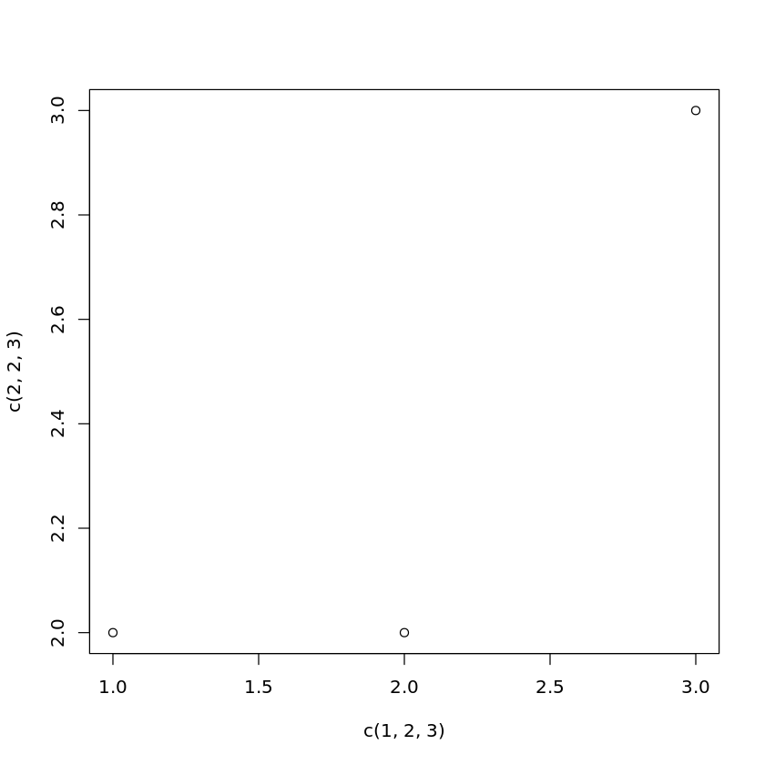

```r
plot(c(1,2,3), c(2,2,3))
```

Ajoutez le titre `Mon graphique` avec l’argument `main`.

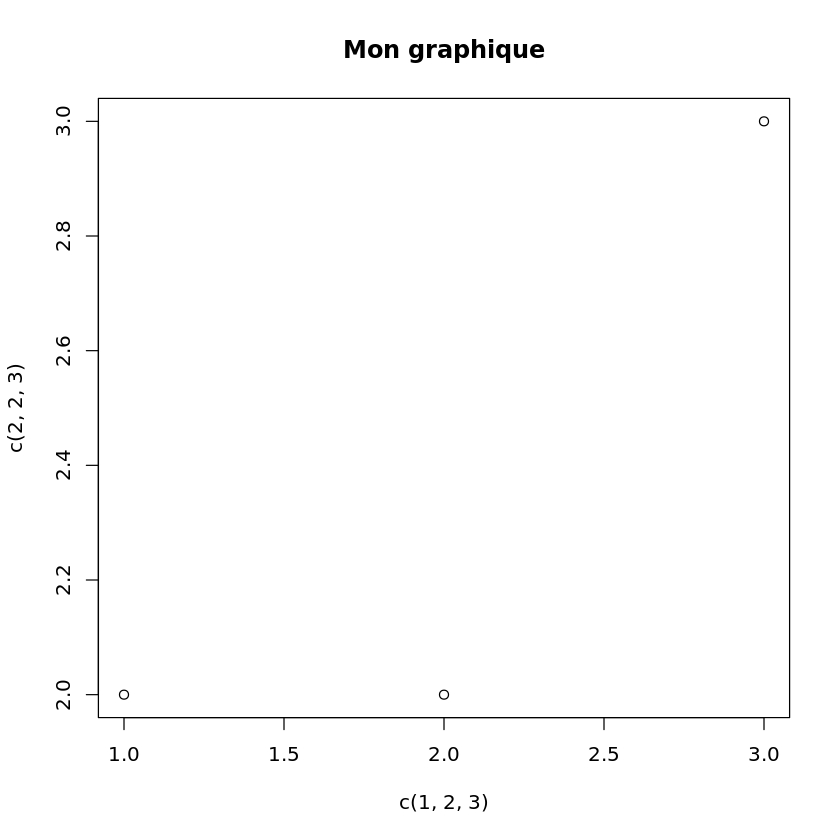

```r
plot(c(1,2,3), c(2,2,3), main = "Mon graphique")
```

Sauvegardez ce graphique en format `.jpeg` sous le nom `initial_graph.jpeg` avec la fonction `jpeg()` suivie de `dev.off()`

```r
jpeg("initial.graph.jpeg")
plot(c(1,2,3), c(2,2,3))
dev.off()
```

**png:** 2

### 2. Personnalisation du graphique

#### 2.1. Modification de paramètres dans la fonction primaire `plot()`

Recommencez ce graphique en personnalisant l’affichage avec les options ou fonctions suivantes pas à pas (faites un nouveau graphique à chaque étape en ajoutant le nouveau paramètre):

- `xlim` et `ylim` : délimitez l’affichage des échelles des deux axes entre 0 et 4

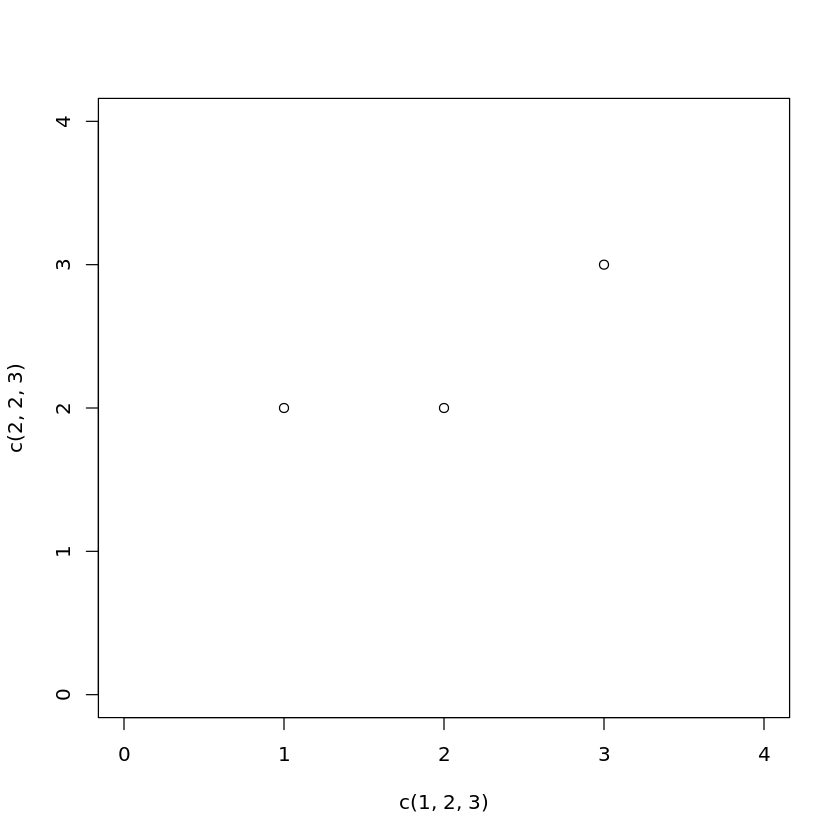

```r
plot(c(1,2,3), c(2,2,3),xlim = c(0,4), ylim = c(0,4))
```

- `cex` : doublez la taille des points

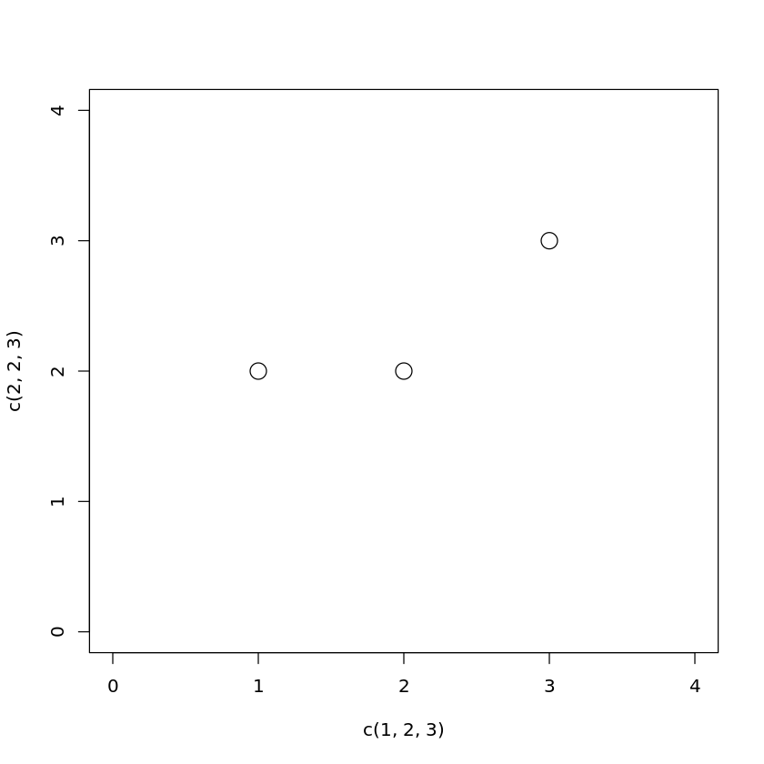

```r
plot(c(1,2,3), c(2,2,3), cex = 2, xlim = c(0,4), ylim = c(0,4))
```

- `pch` : donnez d’abord une forme de cercle plein à chaque point ;

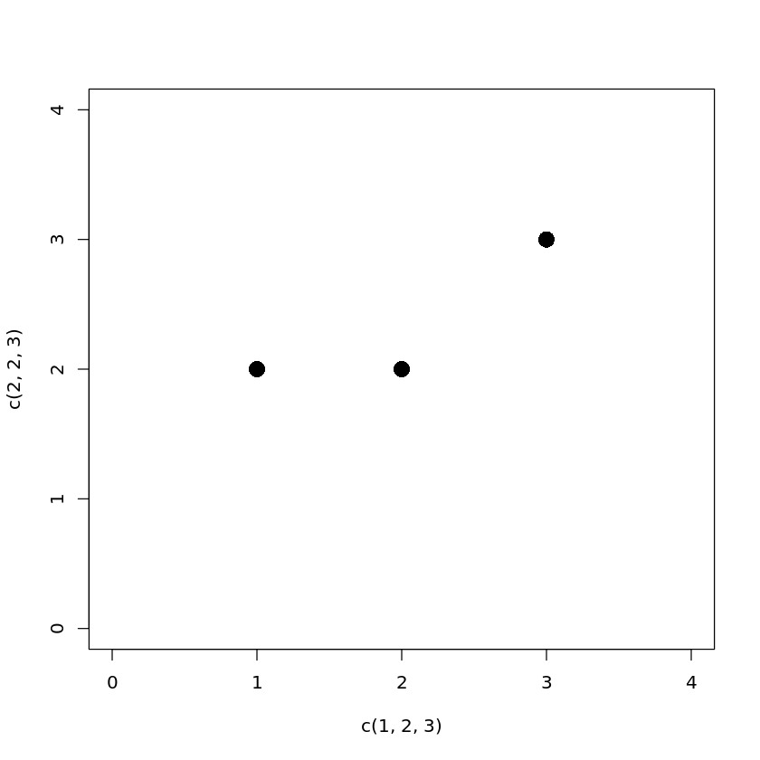

```r
plot(c(1,2,3), c(2,2,3), cex = 2, pch = 16, xlim = c(0,4), ylim = c(0,4))# ou pch=19 ou 20 selon la taille choisie
```

puis recommencez en spécifiant une forme différente pour chaque point :

```
   - le 1er sous forme d’une croix (comme un +)
   - le 2ème sous forme d’un triangle pointé vers le bas vide
   - le 3ème sous forme d’un losange plein
```

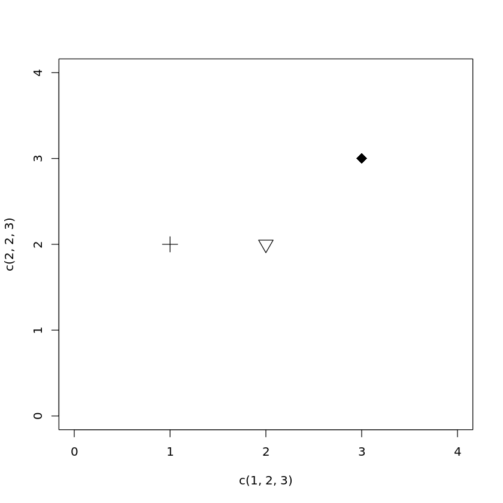

```r
plot(c(1,2,3), c(2,2,3), cex = 2, pch = c(3,6,18), xlim = c(0,4), ylim = c(0,4))
```

- `palette()` : trouvez les couleurs de votre session et identifiez l’indice de la couleur grise

```r
palette() # le nom des couleurs de base est affiche
index_grey <- grep("gray", palette())#gray=grey dans R!!!
```

1. 'black'

2. 'red'

3. 'green3'

4. 'blue'

5. 'cyan'

6. 'magenta'

7. 'yellow'

8. 'gray'

- `col` : mettez tous les points en gris puis donnez une couleur différente à chaque point :

  ```
    rouge pour le 1er
    bleu pour le 2nd
    contour en magenta et fond en cyan pour le 3ème (avec l’option bg en plus)
  ```

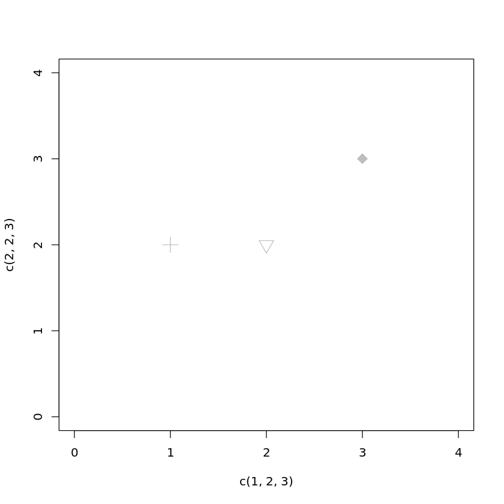

```r
plot(c(1,2,3), c(2,2,3), cex = 2, pch = c(3,6,18), xlim = c(0,4), ylim = c(0,4), col = index_grey)# vous pouvez ecrire col="gray" ou col=8  ou col=grep("gray", palette()) indifferemment
```

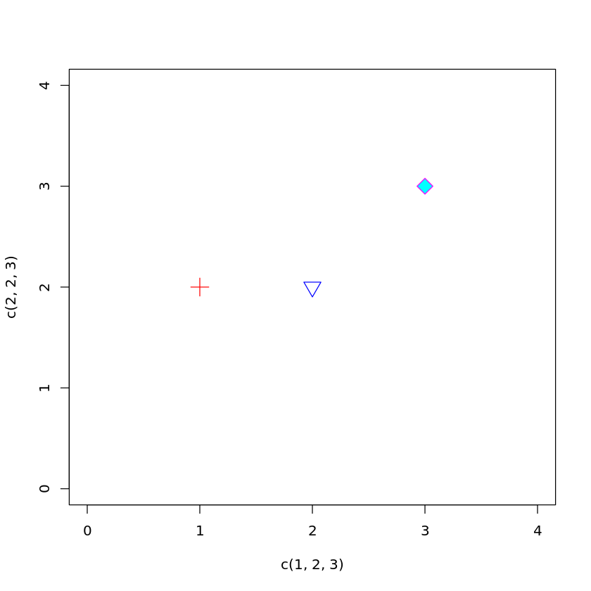

```r
plot(c(1,2,3), c(2,2,3), cex = 2, pch = c(3,6,23), xlim = c(0,4), ylim = c(0,4), col = c("red", "blue", "magenta"), bg = "cyan")
```

- `lwd` : doublez la largeur des traits tracés (ici des points)

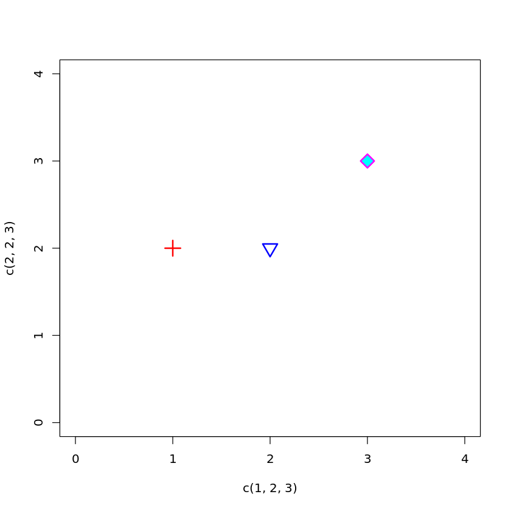

```r
plot(c(1,2,3), c(2,2,3), cex = 2, pch = c(3,6,23), xlim = c(0,4), ylim = c(0,4), col = c("red", "blue", "magenta"), bg = "cyan", lwd = 2)
```

- `bty` : retirez la cadre entourant le graphique pour ne conserver que les axes

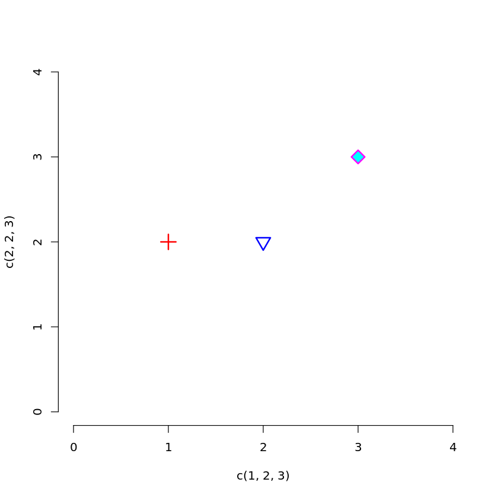

```r
plot(c(1,2,3), c(2,2,3), cex = 2, pch = c(3,6,23), xlim = c(0,4), ylim = c(0,4), col = c("red", "blue", "magenta"), bg = "cyan", lwd = 2, bty = "n")
```

- `xlab` et `ylab` = nommez les axes Axe des abscisses et Axe Y.

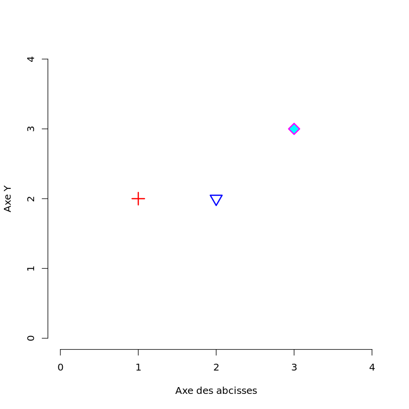

```r
# et enfin, cette fois-ci avec le nom des axes et en ecrivant chaque argument l'un en dessous de l'autre pour plus de lisibilite (sans oublier la virgule entre chaque!!!)
plot(c(1,2,3), c(2,2,3),
     cex = 2, pch = c(3,6,23),
     xlim = c(0,4), ylim = c(0,4),
     col = c("red", "blue", "magenta"),
     bg = "cyan",
     lwd = 2,
     bty = "n",
     xlab = "Axe des abcisses",
     ylab = "Axe Y")
```

#### 2.2. Utilisation de fonctions graphiques secondaires

- Ajoutez un 4ème point sous forme d’un cercle plein gris aux coordonnées (1.5, 3) avec la fonction `points()`

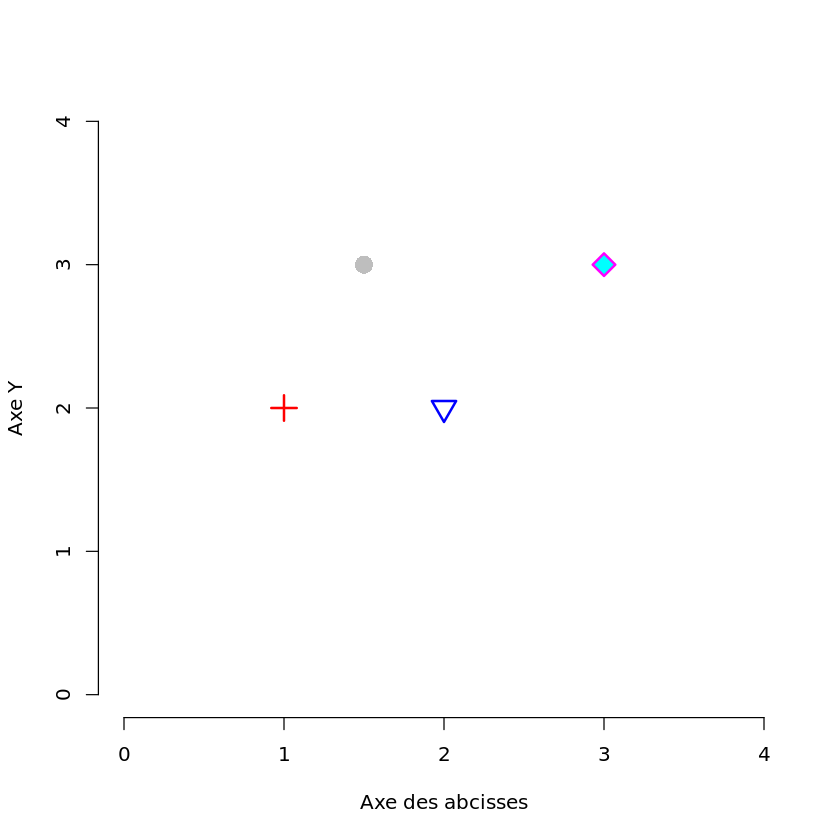

```r
plot(c(1,2,3), c(2,2,3),
     cex = 2, pch = c(3,6,23),
     xlim = c(0,4), ylim = c(0,4),
     col = c("red", "blue", "magenta"),
     bg = "cyan",
     lwd = 2,
     bty = "n",
     xlab = "Axe des abcisses",
     ylab = "Axe Y")
points(1.5, 3, pch = 16, col = "gray", cex = 2) # points() est une fonction graphique secondaire
```

- Ajoutez une ligne pointillée de couleur verte en position horizontale à l’ordonnée 1 avec la fonction `abline()` et en particulier l’option `lty`

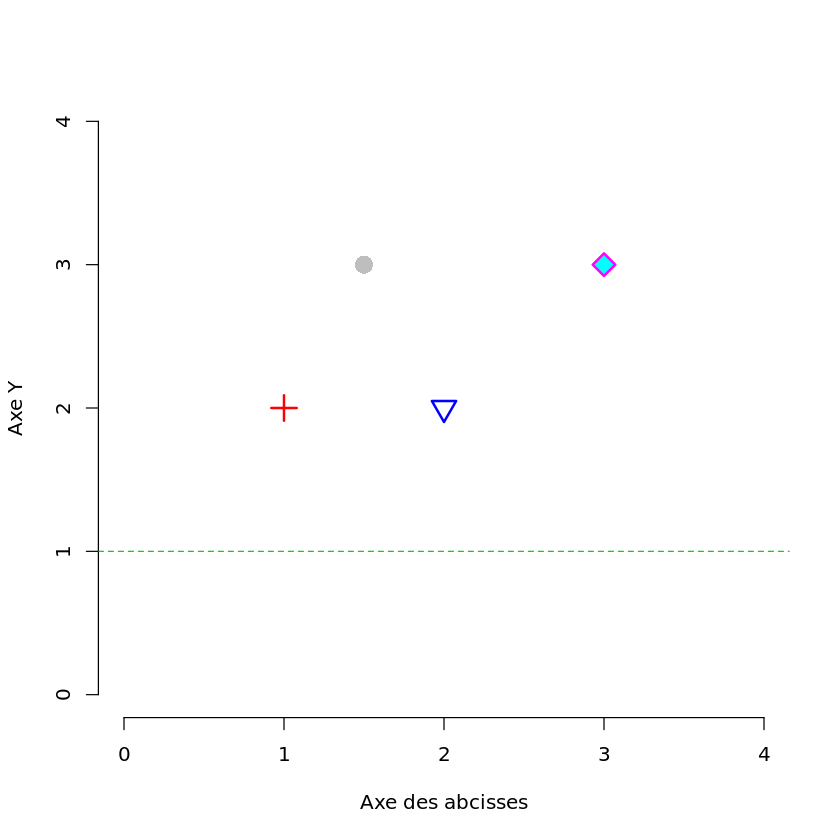

```r
plot(c(1,2,3), c(2,2,3),
     cex = 2, pch = c(3,6,23),
     xlim = c(0,4), ylim = c(0,4),
     col = c("red", "blue", "magenta"),
     bg = "cyan",
     lwd = 2,
     bty = "n",
     xlab = "Axe des abcisses",
     ylab = "Axe Y")
points(1.5, 3, pch = 16, col = "gray", cex = 2) # points() est une fonction graphique secondaire
abline(h = 1, col = "green3", lty = 2) # abline() est aussi une fonction secondaire
```

#### 2.3. Légende

Ajoutez une légende avec la fonction `legend()` dans le coin en haut à droite et aidez-vous des arguments :

```
`col`, `pt.bg`, `pt.lwd`  et `pt.cex`: pour respecter les couleurs, formes des points que vous mettrez à la taille 1.5
`legend` : pour nommer vos points A, B, C et D
`title` : pour donner un nom Mes 4 points à la légende
`horiz` : pour positionner les points côte à côte plutôt que les uns en dessous des autres
```

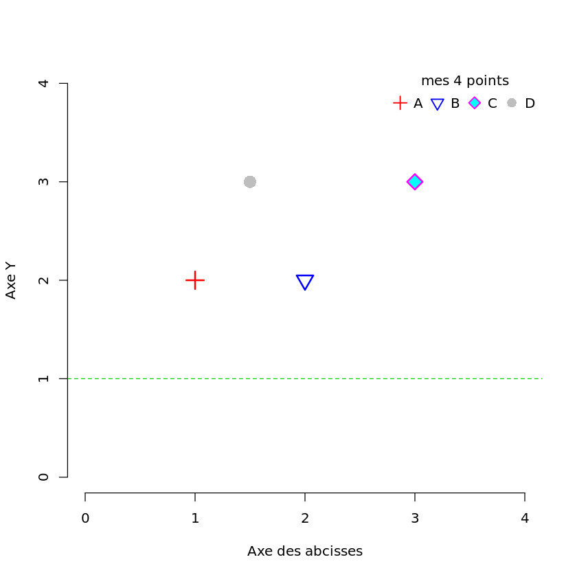

```r
plot(c(1,2,3), c(2,2,3),
     cex = 2, pch = c(3,6,23),
     xlim = c(0,4), ylim = c(0,4),
     col = c("red", "blue", "magenta"),
     bg = "cyan",
     lwd = 2,
     bty = "n",
     xlab = "Axe des abcisses",
     ylab = "Axe Y")
points(1.5, 3, pch = 16, col = "gray", cex = 2) # points() est une fonction graphique secondaire
abline(h = 1, col = "green3", lty = 2) # abline() est aussi une fonction secondaire
legend("topright",
       legend = c("A","B","C","D"),
       col = c("red", "blue", "magenta", "gray"),
       pch = c(3,6,23, 16),
       pt.bg = "cyan",
       pt.cex = 1.5,
       pt.lwd = 1.5,
       title = "mes 4 points",
       bty = "n",
       horiz = T)
```

#### 2.4 Version finale sauvegardée

- Donnez le titre `Mon graphique personnalisé` à votre figure

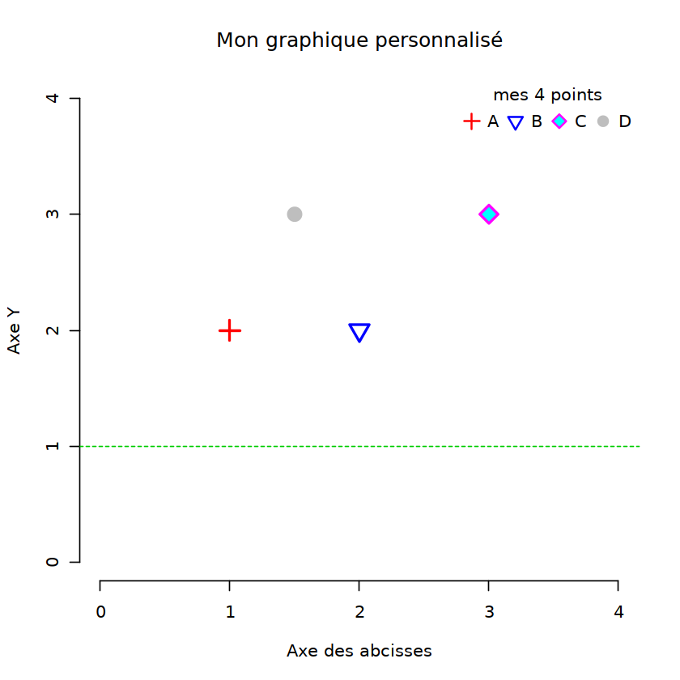

```r
plot(c(1,2,3), c(2,2,3),
     cex = 2, pch = c(3,6,23),
     xlim = c(0,4), ylim = c(0,4),
     col = c("red", "blue", "magenta"),
     bg = "cyan",
     lwd = 2,
     bty = "n",
     xlab = "Axe des abcisses",
     ylab = "Axe Y")
points(1.5, 3, pch = 16, col = "gray", cex = 2) # points() est une fonction graphique secondaire
abline(h = 1, col = "green3", lty = 2) # abline() est aussi une fonction secondaire
legend("topright",
       legend = c("A","B","C","D"),
       col = c("red", "blue", "magenta", "gray"),
       pch = c(3,6,23, 16),
       pt.bg = "cyan",
       pt.cex = 1.5,
       pt.lwd = 1.5,
       title = "mes 4 points",
       bty = "n",
       horiz = T)
title("Mon graphique personnalisé")
# ici j'ai utilise la fonction secondaire title() pour ajouter un titre, mais j'aurais pu utiliser l'argument "main" lors de la fonction plot:
# plot(c(1,2,3), c(2,2,3),
#      cex = 2, pch = c(3,6,23),
#      xlim = c(0,4), ylim = c(0,4),
#      col = c("red", "blue", "magenta"),
#      bg = "cyan",
#      lwd = 2,
#      bty = "n",
#      xlab = "Axe des abcisses",
#      ylab = "Axe Y",
#      main="Mon graphique personnalise")
```

- Sauvegardez-la en format pdf avec le nom `cutom_graph.pdf`

```r
pdf("custom_graph.pdf")
plot(c(1,2,3), c(2,2,3),
     cex = 2, pch = c(3,6,23),
     xlim = c(0,4), ylim = c(0,4),
     col = c("red", "blue", "magenta"),
     bg = "cyan",
     lwd = 2,
     bty = "n",
     xlab = "Axe des abcisses",
     ylab = "Axe Y",
     main = "Mon graphique personnalis?")
points(1.5, 3, pch = 16, col = "gray", cex = 2)
abline(h = 1, col = "green3", lty = 2)
legend("topright", legend = c("A","B","C","D"),
       col = c("red", "blue", "magenta", "gray"),
       pch = c(3,6,23, 16),
       pt.bg = "cyan", pt.cex = 1.5, pt.lwd = 1.5,
       title = "mes 4 points",
       bty = "n",
       horiz = T)
dev.off()
```

**png:** 2

**Tip :** *fonctions recommandées pour l'exercice:*

```
jpeg()
pdf()
dev.off()
plot()
palette()
grep()
points()
abline()
legend()
title()
```

*=> Pour aller plus loin:*

Jouez avec l'affichage des axes:

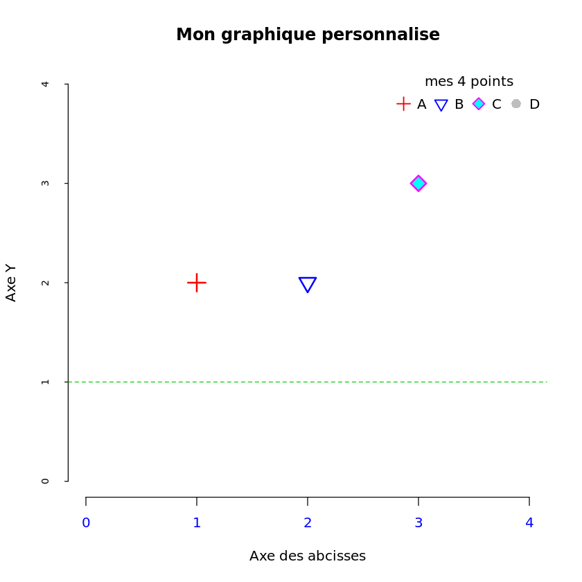

```r
plot(c(1,2,3), c(2,2,3),
     cex = 2, pch = c(3,6,23),
     xlim = c(0,4), ylim = c(0,4),
     col = c("red", "blue", "magenta"),
     bg = "cyan", lwd = 2, bty = "n",
     xlab = "Axe des abcisses", ylab = "Axe Y",
     xaxt = "n", yaxt = "n" )
axis(1, at = 0:4,labels = F )
mtext(0:4,side = 1,at = 0:4, line = 1,col = "blue")
axis(2, at = 0:4, tcl = -0.2, cex = 0.7, labels = F )
mtext(0:4,side = 2,at = 0:4, line = 1, cex = 0.7)
abline(h = 1, col = "green3", lty = 2)
legend("topright", legend = c("A","B","C","D"),
       col = c("red", "blue", "magenta", "gray"),
       pch = c(3,6,23, 16), pt.bg = "cyan",
       pt.cex = 1.5, pt.lwd = 1.5,
       title = "mes 4 points",
       bty = "n", horiz = T)
title("Mon graphique personnalise")
```

## Exercice 2: représentations graphiques de données qualitatives

Importez dans R le fichier `motorisation.txt` qui est sur la page du cours ou dans dans: `/shared/procjets/dubii2021/trainers/module3/data`.

Générez un camembert de la répartition des différentes motorisations et choisissez vous-mêmes des couleurs.

Générez également un diagramme en bâtons avec les proportions (fréquences relatives) des différentes motorisations colorées comme dans le camembert.

Disposez à présent les deux graphes côte à côte sur un même graphique. Essayez dans une premier temps de faire chaque graphique independamment avec les bonnes commandes avant de les afficher sur une même fenêtre graphique

*Note: lorsque vous utilisez Rstudio, une erreur peur se produire si votre fenetre graphique est trop petite, compte tenu des marges et de la taille de votre ecran-> pensez alors a redimensionner la fenetre graphique avant de lancer vos commandes graphiques*

**Tip :***fonctions recommandées : `read.table()`, `table()`, `pie()`, `barplot()` `par()`avec l’argument `mfrow`*

Avant de lire ce fichier et de l'assigner dans un objet R, ouvrez le avec un editeur de texte pour voir s'il y a une en-tete, combien il contient de lignes, de colonnes et quel est leur separateur (espace, tabulation, virgule, point virgule, etc...) Ici motorisation.txt est un fichier texte de 22 lignes, avec une seule colonne (donc vous pouvez garder le separateur de champs "espace" par defaut dans la commande read.table qui suit), et sans en-tete (donc il faut le specifier avec l'argument header sinon votre premiere valeur serait lue comme un nom de colonne par defaut)

```r
motorisation <- read.table("/shared/projects/dubii2021/trainers/module3/data/motorisation.txt", header = F, stringsAsFactors = F) # nommez votre objet R present d
```

```r
# Alternativement, si le fichier motorisation est dans votre repertoire de travail ou un autre, donnez son chemin absolu ou relatif
# motorisation <- read.table("./motorisation.txt", header = F, stringsAsFactors = F)
```

Toujours verifier ensuite la structure des objets importés et se demander si elle est conforme a ce que vous souhaitez!

```r
str(motorisation)
```

```
'data.frame':	22 obs. of  1 variable:
 $ V1: chr  "Hybride" "Diesel" "Diesel" "Essence" ...
```

On ajoute un nome à la variable V1 pour plus de lisibilité:

```r
names(motorisation) <- "type_de_motorisation"
```

- Pour le pie chart:

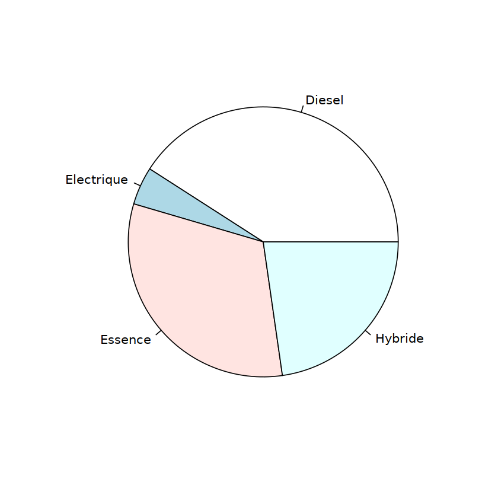

```r
pie(table(motorisation$type_de_motorisation))
```

Si je choisis mes couleurs:

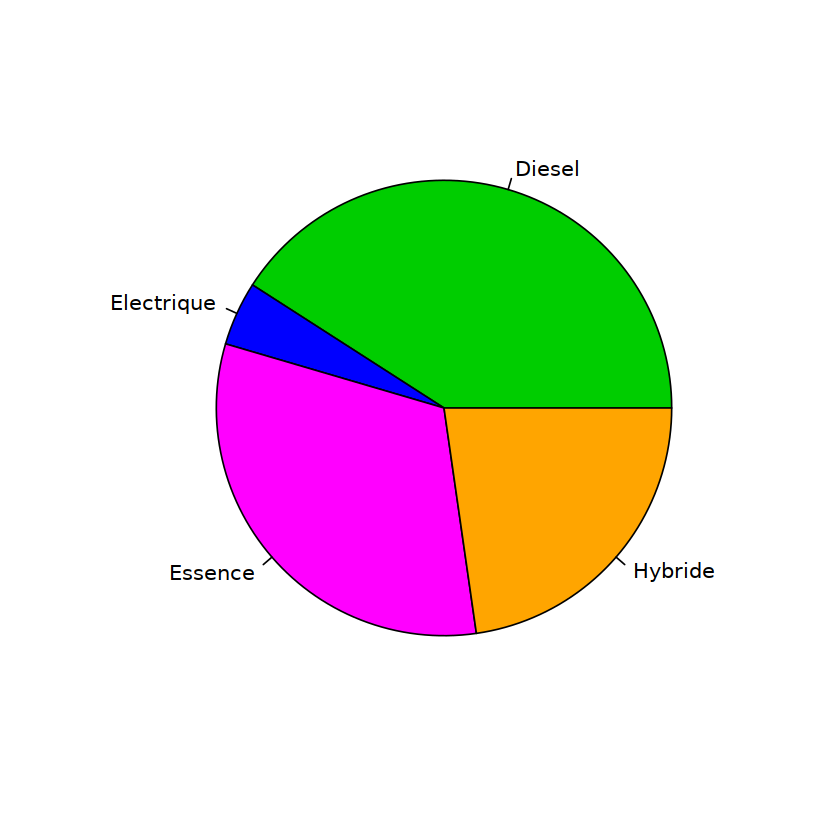

```r
pie(table(motorisation$type_de_motorisation), col = c("green3","blue","magenta","orange"))
```

N’hesitez pas à decomposer la commande ci-dessus élement par élement pour bien la comprendre en tapant successivement:

```r
? pie
table(motorisation$type_de_motorisation) #cette commande vous retourne un tableau de contingence comptant le nombre d'observationns de chaque valeur de la variable "type de motorisation". C'est ce qui est le plus pratique! Il s'agit d'un objet R a une seule dimension.
```

```
    Diesel Electrique    Essence    Hybride
         9          1          7          5
```

| pie {graphics} | R Documentation |
| --- | --- |

Pie Charts

Description

Draw a pie chart.

Usage

```
pie(x, labels = names(x), edges = 200, radius = 0.8,
    clockwise = FALSE, init.angle = if(clockwise) 90 else 0,
    density = NULL, angle = 45, col = NULL, border = NULL,
    lty = NULL, main = NULL, ...)
```

Arguments

[output not shown]

Note

Pie charts are a very bad way of displaying information. The eye is good at judging linear measures and bad at judging relative areas. A bar chart or dot chart is a preferable way of displaying this type of data.

Cleveland (1985), page 264: “Data that can be shown by pie charts always can be shown by a dot chart. This means that judgements of position along a common scale can be made instead of the less accurate angle judgements.” This statement is based on the empirical investigations of Cleveland and McGill as well as investigations by perceptual psychologists.

References

Becker, R. A., Chambers, J. M. and Wilks, A. R. (1988) *The New S Language*. Wadsworth & Brooks/Cole.

Cleveland, W. S. (1985) *The Elements of Graphing Data*. Wadsworth: Monterey, CA, USA.

See Also

`dotchart`.

Examples

[output not shown]

[Package *graphics* version 4.0.2 ]

```r
# Si besoin, vous pouvez extraire les noms attribues a ces valeurs avec la commande
names(table(motorisation$type_de_motorisation))
```

1. 'Diesel'

2. 'Electrique'

3. 'Essence'

4. 'Hybride'

```r
palette() # n'est pas incluse dans la fonction pie() mais vous sert a connaitre les couleurs utilisees par defaut dans votre session R
```

1. 'black'

2. '#DF536B'

3. '#61D04F'

4. '#2297E6'

5. '#28E2E5'

6. '#CD0BBC'

7. '#F5C710'

8. 'gray62'

```r
c("green3","blue","magenta","orange")# vous definissez ici le vecteur pour l'argument col avec 4 elements: une couleur par type possible de motorisation; les couleurs seront affichees dans l'odre alphabetique de chacune des 4 valeurs de la variable "type de motorisation"
```

1. 'green3'

2. 'blue'

3. 'magenta'

4. 'orange'

Alternativement: vous pouviez utiliser la commande `pie()` sans utiliser de tableau de contingence en donnant comme argument x un vecteur avec les comptes de chaque valeur comme ci-dessous

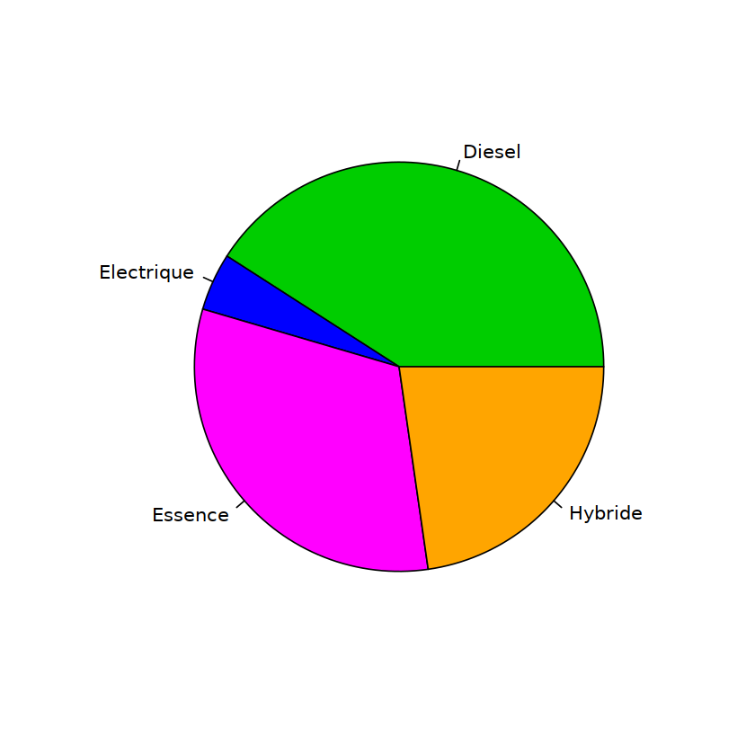

```r
pie(c(9,1,7,5), labels = c("Diesel","Electrique", "Essence", "Hybride"),
    col = c("green3","blue","magenta","orange"))
```

Vous pouvez ajouter l'argument clocwise=T pour changer l'orientation des parts Ici, j'ai ecrit `labels=c("Diesel","Electrique", "Essence", "Hybride")` mais on aurait pu ecrire egalement `labels = names(table(motorisation$type_de_motorisation))` ou `labels = sort(unique(motorisation$type_de_motorisation)` car `unique()` retourne chaque occurence/valeur possible de la variable et la fonction `sort()` les trie par ordre alphanumerique

Enfin, si vous voulez afficher les parts du camembert par ordre croissant, vous pouvez appliquer la fonction `sort()` sur la valeur obtenue par la commande (table(motorisation$type_de_motorisation))`.

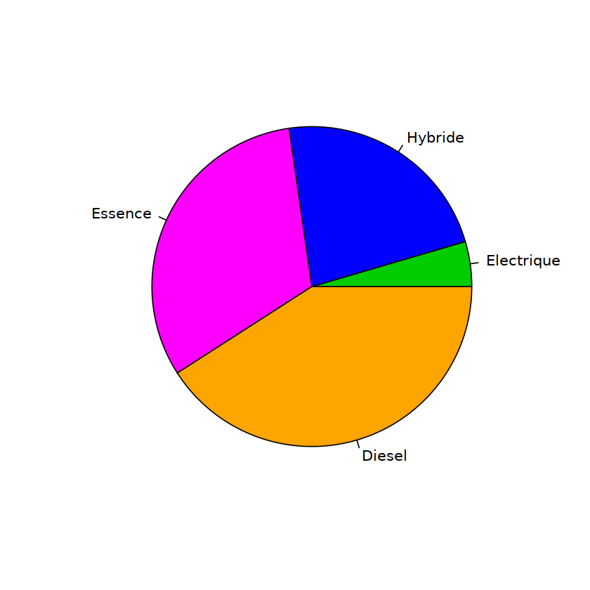

```r
pie(sort(table(motorisation$type_de_motorisation)), col = c("green3","blue","magenta","orange")) # les couleurs sont attribuées dans le nouvel ordre...qui est peut etre mieux car diesel n'est plus en vert!
```

- pour le barplot:

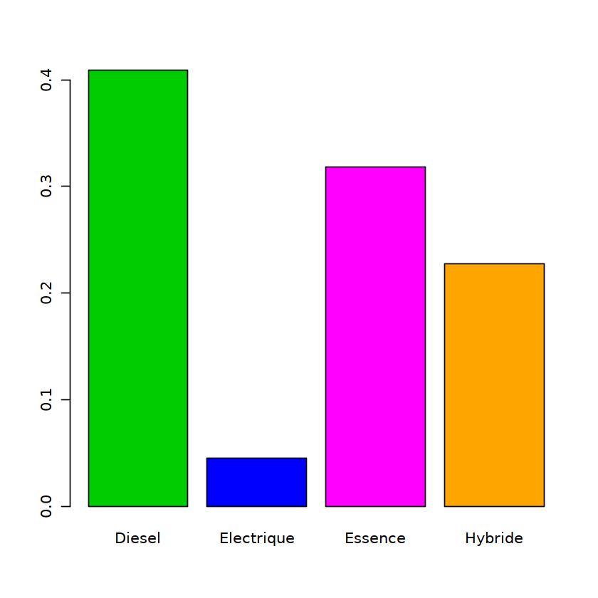

```r
barplot(table(motorisation$type_de_motorisation)/length(motorisation$type_de_motorisation),
        col = c("green3","blue","magenta","orange"))
```

Il s'agit bien d'un barplot (diagramme en batons) adapté a des donnees qualitatives ou quantitatives discrètes et non d'un histogramme adapté a des variables continues

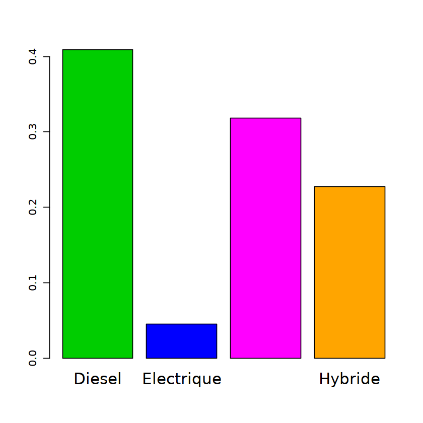

```r
barplot(table(motorisation$type_de_motorisation)/length(motorisation$type_de_motorisation),
        cex.names = 1.5,
        col = c("green3","blue","magenta","orange"))
```

Il est aussi possible d’utiliser barplot avec une matrice comme argument `x`. Dans ce cas, par defaut avec l’argument `beside=F`, les élements du diagramme en baton seront empilés.

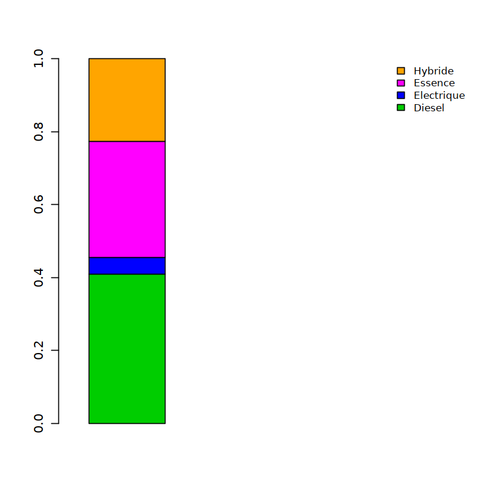

```r
barplot(matrix(table(motorisation$type_de_motorisation)/length(motorisation$type_de_motorisation)),
        col = c("green3","blue","magenta","orange"),
        legend.text = unique(sort(motorisation$type_de_motorisation)),
        args.legend = list(x = "topright", cex = 0.8, bty = "n"),
        width = 1,
        xlim = c(0,5) )
```

Si vous voulez les afficher du plus grand au plus petit effectif, ajouter `sort()` en precisant `decreasing=T`

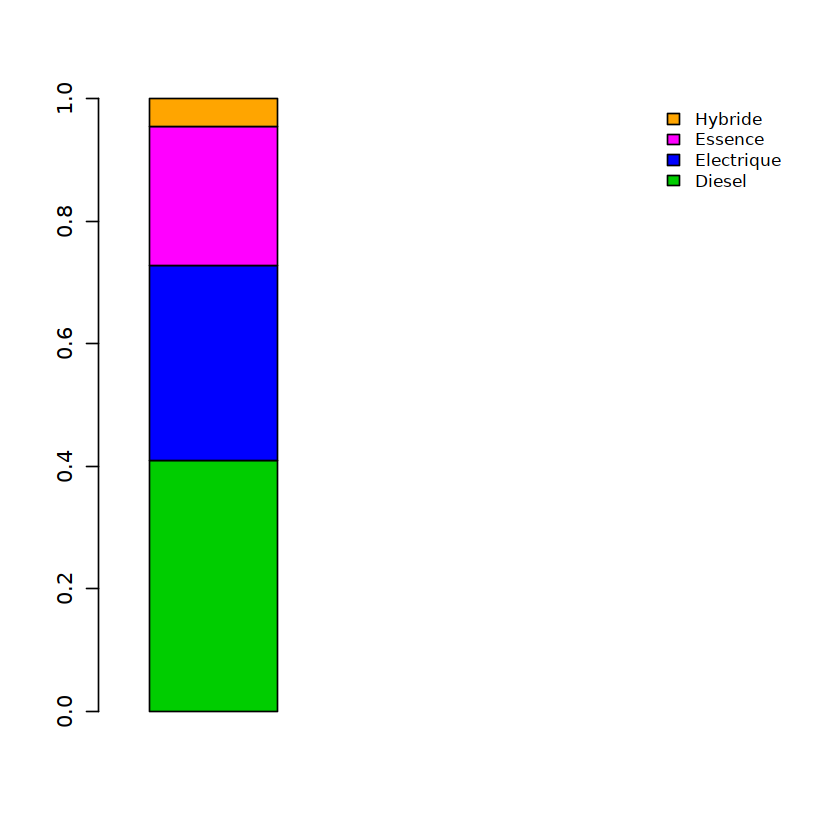

```r
barplot(matrix(sort(table(motorisation$type_de_motorisation)/length(motorisation$type_de_motorisation),decreasing = T)),
        col = c("green3","blue","magenta","orange"),
        legend.text = unique(sort(motorisation$type_de_motorisation)),
        args.legend = list(x = "topright", cex = 0.8, bty = "n"),
        width = 1,
        xlim = c(0,5) )
```

- Pour afficher les 2 plots dans une meme fenetre graphique:

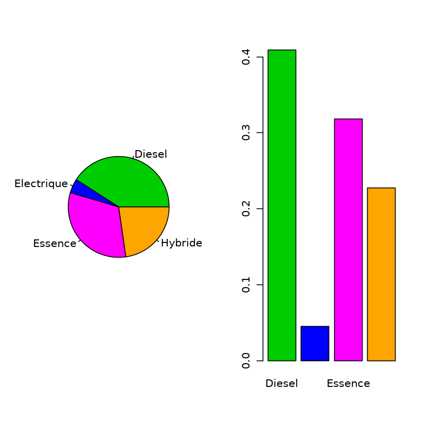

```r
opar <- par()
par(mfrow = c(1,2))
pie(table(motorisation$type_de_motorisation), col = c("green3","blue","magenta","orange"))
barplot(table(motorisation$type_de_motorisation)/length(motorisation$type_de_motorisation),col = c("green3","blue","magenta","orange"))
suppressWarnings(par(opar, warn=F))# avec supressWarnings() j'évite l'affichage des warnings
```

=> Version finale pour aller plus loin en integrant des alternatives décrites pour chaque figure et avec les bonnes règles d’affichage du script R:

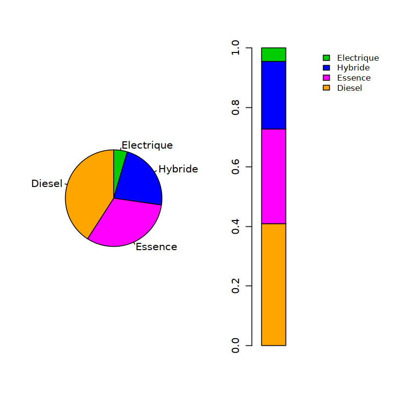

```r
opar <- par()
par(mfrow = c(1,2))
pie(sort(table(motorisation$type_de_motorisation)),
    col = c("green3","blue","magenta","orange"),
    clockwise = T)
barplot(matrix(sort(table(motorisation$type_de_motorisation)/length(motorisation$type_de_motorisation),
                     decreasing = T)),
         col = c("orange","magenta","blue","green3"),
         legend.text = names(sort(table(motorisation$type_de_motorisation)
                                  ,decreasing = T)),
         args.legend = list(x = "topright", cex = 0.8, bty = "n"),
         width = 1,
         xlim = c(0,5))
suppressWarnings(par(opar))
```

Vous noterez qu’il est préférable de visualiser les donnees qualitatives, comme ici le type de motorisation, au moyen d’un diagramme en bâtons. Cela vous ai rappele en ‘Note’ dans la fenetre d’aide de la fonction pie!

## Exercice 3: représentation graphique de la distribution d’une variable quantitative continue

Tirez aléatoirement un ensemble de 100 nombres compatibles avec une distribution normale de moyenne 10 et d’écart type 5.

Sauvegardez-les dans un objet R.

**Tip :** *fonction recommandée : `norm()`*

```r
myrandomdata <- rnorm(100, mean = 10, sd = 5)# bien penser à assigner le resultat de votre tirage dans un objet, sinon, les valeurs changent à chaque fois que vous effectuez un tirage avec la commande rnorm!
```

Tracez la représentation histogramme des valeurs obtenues.

**Tip :***fonction recommandée : `hist()`*

Changez le nombre d’intervalles de l’histogramme : environ 5, 50 et 100.

**Tip :***fonction recommandée : `hist()` avec l'argument `breaks`*

Tracez également une boite à moustache horizontale de ces data.

**Tip :***fonction recommandée : `boxplot()`*

Affichez les 3 histogrammes et le boxplot les uns en dessous des autres dans une même fenêtre graphique.

**Tip :***fonction recommandée : `par()` avec l'argument `mfrow`*

Je ne vous détaille pas ici chaque graphique, je les empile tout de suite:

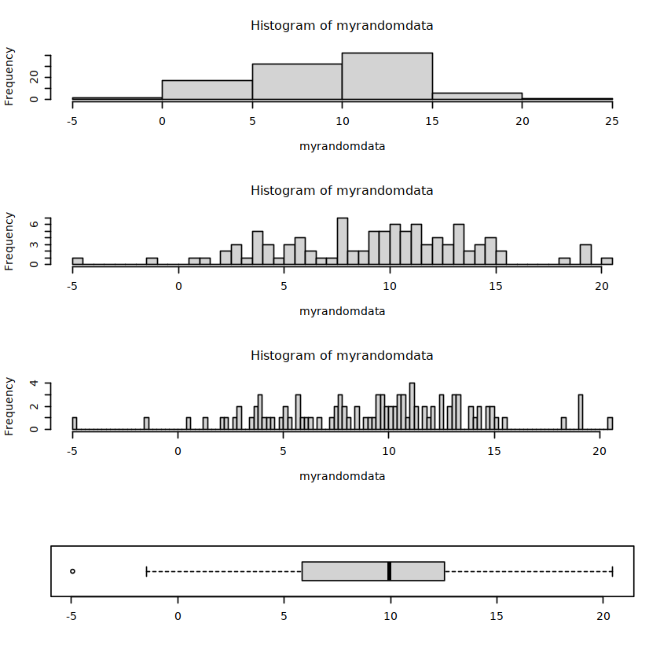

```r
opar <- par()
par(mfrow = c(4,1))
hist(myrandomdata, breaks = 5)
hist(myrandomdata, breaks = 50)
hist(myrandomdata, breaks = 100)
boxplot(myrandomdata, horizontal = T)
```

## Exercice 4: représentations graphiques de données quantitatives

Copiez dans votre environnement le fichier `airquality.png` disponible avec la commande suivante:

```r
file.copy("/shared/projects/dubii2021/trainers/module3/data/airquality.png", "./airquality.png", overwrite=TRUE)
```

TRUE

Ouvrez cette image dans le lab en double cliquant dessus.

Récupérez le jeu de données `airquality` disponible sous R.

Créez les graphes de la figure ci-dessus avec ce jeu de données.

**Tip :***fonctions recommandées : `data()`, `par()` avec les arguments `mfrow` et `mar`, `plot()`, `lines()`, `boxplot()`, `abline()`, `lm()`, `title()`*

```r
data(airquality)
str(airquality)
```

```
'data.frame':	153 obs. of  6 variables:
 $ Ozone  : int  41 36 12 18 NA 28 23 19 8 NA ...
 $ Solar.R: int  190 118 149 313 NA NA 299 99 19 194 ...
 $ Wind   : num  7.4 8 12.6 11.5 14.3 14.9 8.6 13.8 20.1 8.6 ...
 $ Temp   : int  67 72 74 62 56 66 65 59 61 69 ...
 $ Month  : int  5 5 5 5 5 5 5 5 5 5 ...
 $ Day    : int  1 2 3 4 5 6 7 8 9 10 ...
```

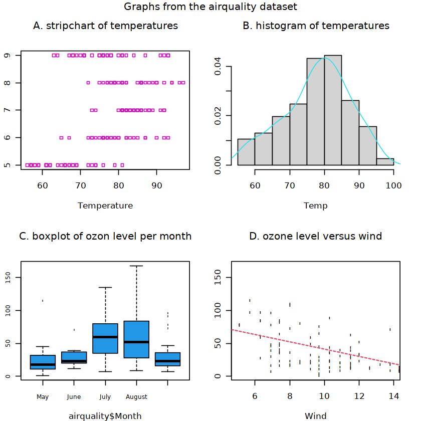

```r
opar <- par()
par(mfrow = c(2,2),
    mar = c(4.1, 2.1, 5.1, 2.1))
stripchart(airquality$Temp~airquality$Month,
           pch = 22,
           xlab = "Temperature", ylab = "Month",
           main = "A. stripchart of temperatures",
           col = 6)
hist(airquality$Temp,
     xlab = "Temp",
     freq = FALSE,
     main = "B. histogram of temperatures")
lines(density(airquality$Tem), col = 5)
boxplot(airquality$Ozone~airquality$Month,
        names = c("May", "June", "July", "August", "September"),
        cex.axis = 0.7,
        col = 4,
        pch = "'",
        main = "C. boxplot of ozon level per month")
plot(airquality$Ozone~airquality$Wind,
     xlab = "Wind",
     ylab = "Ozone",
     xlim = c(5,14),
     pch = "'",
     main = "D. ozone level versus wind")
abline(lm(airquality$Ozone~airquality$Wind),
       col = 2, lty = 2, lwd = 1.5)
title("Graphs from the airquality dataset", outer = T, line = -1)
suppressWarnings(par(opar))
```

For the boxplots, you could also have generated a factor with names to each level:

```r
fmonth <- factor(airquality$Month,levels = 5:9)
levels(fmonth) <- c("May","June","July","August","September")
boxplot(airquality$Ozone ~ fmonth ,
        col = "blue",
        ylab = "Ozone",
        main = "C. boxplot of ozon level per month")
```

**IMPORTANT NOTE ON NAMES OF VARIABLES:** Here for boxplot as for most R functions, you may enter the name of the dataframe for once with the argument `data`, and then just put the name of the variables without repeating the name of the dataframe:

```r
boxplot(data = airquality, Ozone~fmonth , col = "blue", ylab = "Ozone", main = "C. boxplot of ozon level per month")
```

Alternatively, you may use `attach()` to access to the variables of the dataset directly by their name, then enter your commands, and then `detach()` once finsihed. I don't recommand this last method as we often forget to detach.

```r
attach(airquality)
boxplot(Ozone ~ fmonth , col = "blue", ylab = "Ozone", main = "C. boxplot of ozon level per month")
detach(airquality)
```

**Caution:**  
Don't forget to save you notebook and export a copy as an **html** file as well  
- Open "File" in the Menu  
- Select "Export Notebook As"  
- Export notebook as HTML  
- You can then open it in your browser even without being connected to the IFB Jupyter hub!